# Mother Jones Data

2022-12-15

## Table of Contents

## Data And Background Information

- Four decades of mass shooting cases, from 1982 to 2022.
- Variables are cases, location, date, summary, fatalities, injured, total victims, prior signs of mental health issues, mental health details, weapons obtained illegally, where the weapons were obtained, weapon type, weapon details, race, gender, latitude, longitude, type, and year.
- Case/column: mass shooting event
- Each case leading up to year 2012 was of a mass shooting where at least four people died. And the cases from the years 2013 to 2022 are of mass shootings where at least three people died to match the federal definition of what a mass shooting is.

## Problem Investigated

- What factors can predict total victims in a mass shooting? I assumed that prior signs of mental health issues is a great predictor for total victims.

## Data Wrangling

- Renamed location…8 and location…2 to location_type and location.
- Inner joined regions data set.
- Used separate() function to create city and state columns.
- Used case_when() to reduce gender column (“F,” “M,” “Female,” “Male,” and “Female & Male”), location type column, and race column

## Data Wrangling Continued

- For the race column, one value was “unclear,” so I grouped that with NA. Because if it is not clear, we do not know the race of the person, so it would not be available. I did the same with prior signs of mental health issues, where I put TBD, Unclear, and Unknown under NA to reduce the levels.
- For the shooter age column, there were three NAs. I found their ages in the details columns, so I mutated them and changed those NA to the correct age of the shooter.
- For total victim variables and other variables necessary for this analysis, I made the ones I assumed to be numeric as numeric and not categorical.
- I reduced the levels in multiple categorical variables. For example, some categories had NAs and Unknowns. I put these levels together as one level under NAs.

## Explanatory Data Analysis

### Total Victims Distribution

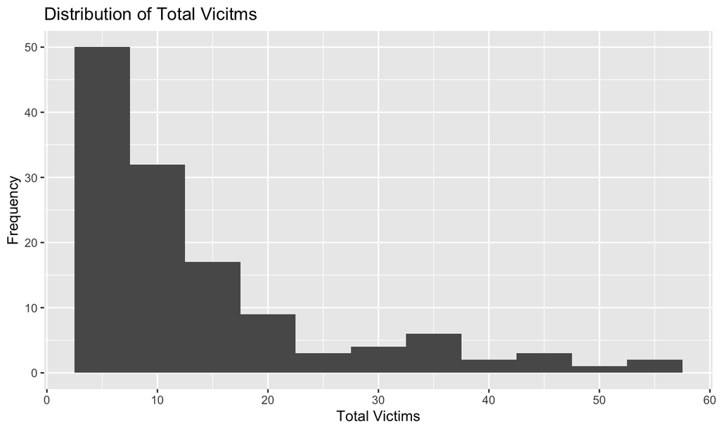

## Explanatory Data Analysis

### Total Victims Summary Statistics

```
## # A tibble: 1 × 5
##    Mean Maximum Minimum Median    SD
##   <dbl>   <dbl>   <dbl>  <dbl> <dbl>
## 1  13.9      55       3     10  11.6
```

## Explanatory Data Analysis

### Age of Shooter Distribution

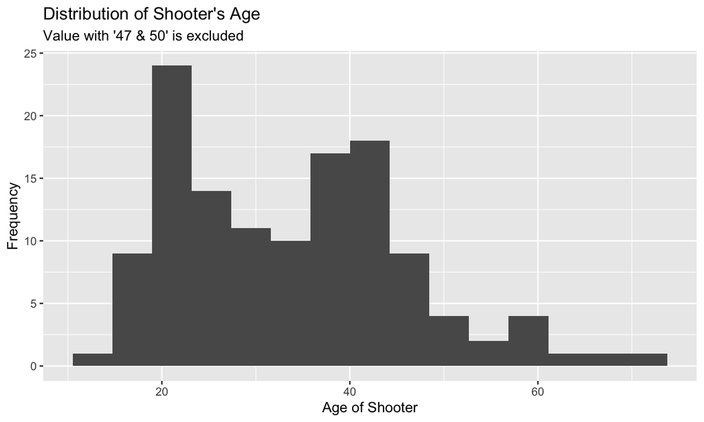

## Explanatory Data Analysis

### Age of Shooter Summary Statistics

```
## # A tibble: 1 × 5
##    Mean Maximum Minimum Median    SD
##   <dbl>   <dbl>   <dbl>  <dbl> <dbl>
## 1  33.7      70      11   33.5  12.5
```

## Explanatory Data Analysis

### Year Histogram

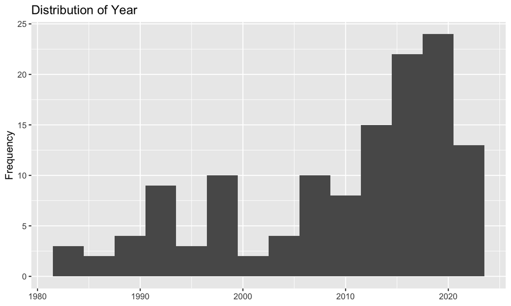

## Explanatory Data Analysis

### Year

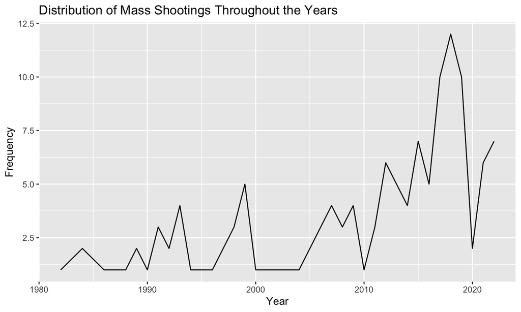

## Taking log of Total Victims

```
## # A tibble: 129 × 1
##    total_victims_log
##                <dbl>
##  1              1.61
##  2              3.97
##  3              1.10
##  4              1.39
##  5              3.64
##  6              2.56
##  7              1.39
##  8              2.40
##  9              2.20
## 10              2.71
## # … with 119 more rows
```

## Finding a Linear Relationship Between log of Total Victims and Age of Shooter

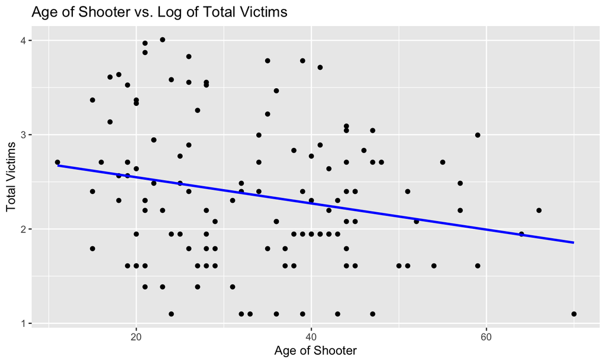

## Age of Shooter Residuals Plot

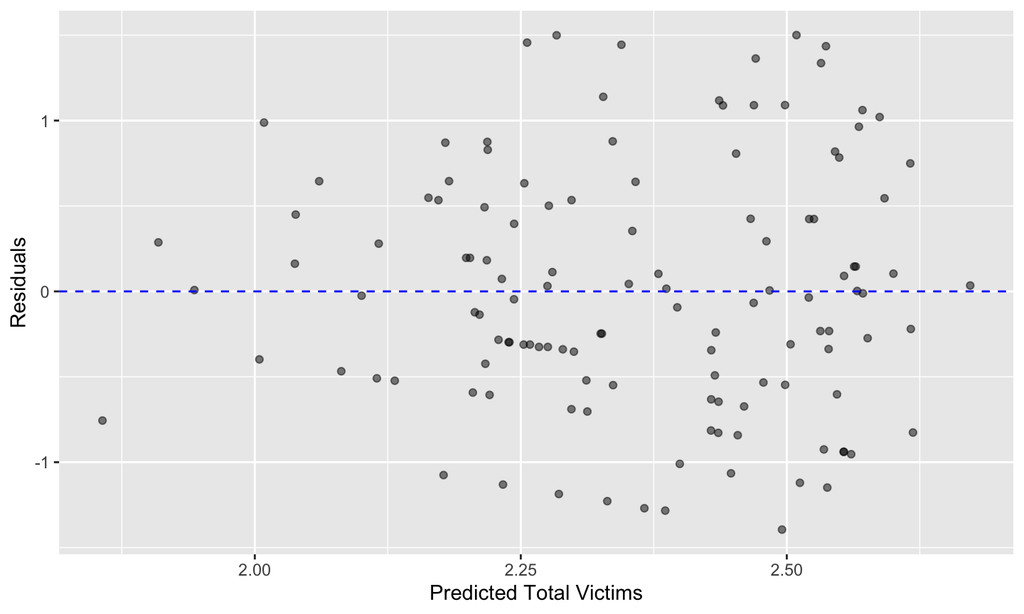

## Age of Shooter Residuals Histogram

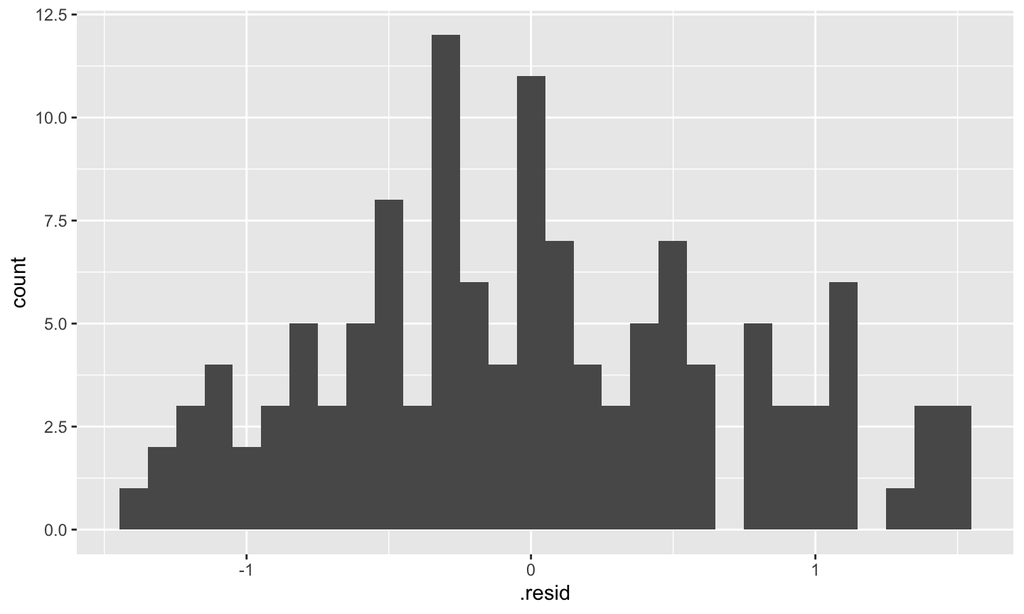